# Range Map Workflow

kemushi54

2023-11-14

This package is designed to facilitate the generation of range maps in ‘Range Map Datasets for Terrestrial Vertebrates across Taiwan’ (Chang et al., 2022, https://doi.org/10.1016/j.dib.2022.108060). For detailed information on the workflow and the dataset, please refer to the associated data paper.

You can access the example code after installing the package. To save the example workflow R code to another location, use: `get_workflow(file_path = "scripts")`. To view the example workflow R code directly, use: `file.show(system.file("examples", "example_workflow.R", package = "RangeMap")`.

## Initialize Project Structure

Create the project structure using the default setting. Refer to `project_structure.R` by using `file.show(system.file("examples", "project_structure.R", package = "RangeMap")` for more details.

```r
# Call the function to create the project structure
project_init()
```

## Load example species and occurrence data.

The content of `sp_list` will use to name the models and range map files in the following steps. The occurrence should have three basic column: `name_c` for the species name used (consistent with `sp_list`), and `longitude` and `latitude` for the WGS84 coordinates.

```r
# Define the list of species
sp_list <- c("紅鳩", "白尾鴝")

# Load example occurrence data
load(system.file("data", "example_occurrence.RData", package = "RangeMap"))
```

Example of occurrence data needed.

| name_c | longitude | latitude |
| --- | --- | --- |
| 紅鳩 | 121.8810 | 25.01970 |
| 紅鳩 | 121.3005 | 24.95321 |
| 紅鳩 | 120.5196 | 22.87390 |
| 白尾鴝 | 120.7824 | 23.08913 |
| 白尾鴝 | 121.1110 | 24.02398 |

## Generate Species Data

Generate species data for species in `sp_list` in GeoJSON format. Save the data in “data_processed/species_data/” by default.

```r
lapply(sp_list, function(sp) {
  # Filter occurrence data for the current species
  sp_data <- db_data %>% filter(name_c == sp)

  # Generate species data using the generate_species_data function
  generate_species_data(sp_data = sp_data, species_name = sp)
})
```

## Construct Species Distribution Model (SDM)

Construct Species Distribution Models (SDMs) for species in `sp_list`. The `env` variable is a list containing stacked environment variables used in MaxEnt, and `maxent_args` represents the MaxEnt argument settings.

This step involves spatial subsampling of the occurrence data and model building using MaxEnt. The model settings include a cloglog transformation of the output, no bias files, the use of 10,000 background points, with a regularization multiplier of one. The process entails running five replicates for each subsampling dataset of each species, retaining 20% of each of these as random test data. This results in the creation of 100 sub-models for each species.

The MaxEnt model results are saved in the “models/” directory by default use name in `sp_list`. The averages of the habitat suitability values from each of these 100 individual sub-models are saved in RDS format in the “results/gis/prediction_avg” directory by default.

```r
lapply(sp_list, function(sp) {
  # Call the construct_sdm function
  construct_sdm(species_name = sp, env = env, maxent_args = maxent_args)
})
```

## Generate Binary Maps

Convert continuous predicted results into binary values based on 11 thresholds provided by MaxEnt. Export a PNG files with 11 plots for each species.

```r
generate_binary_map(species_list = sp_list,
                    file_path = "data_processed/binary_map")
```

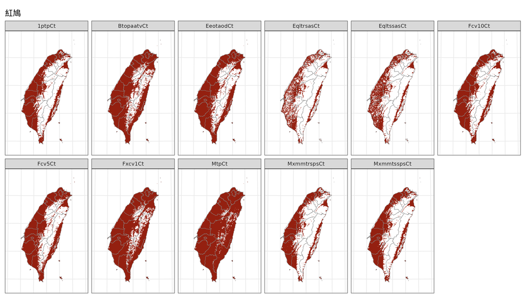

Example binary map product.

## Generate Range Map Layers for Expert Review

Generate range maps with thresholds selected by experts (using the `threshold_maxent` column in the threshold table, with abbreviated threshold names). Export PNG and GeoJSON files for each species.

```r
# Information of threshold select by expert of each species
threshold_table <- data.frame(
  species = sp_list,
  threshold_maxent = c("EqltrsasCt", "BtopaatvCt")
)

# Generate range map layers
generate_range_map_layer(species_list = sp_list,
                         r = 20,
                         threshold_table = threshold_table,
                         output_dir_png = "results/plots/range_map_ori/")
```

Content of threshold table

| species | threshold_maxent |
| --- | --- |
| 紅鳩 | EqltrsasCt |
| 白尾鴝 | BtopaatvCt |

## Generate Final Range Maps Result

Plot final range map result and export PNG file of each species.

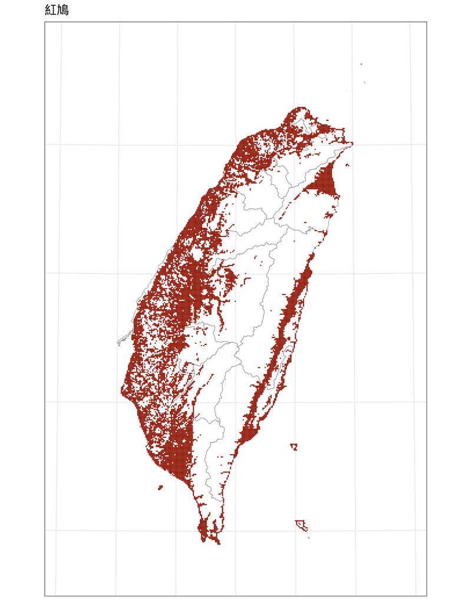

Example range map product.

```r
range_map <- lapply(sp_list, function(sp) {
  # range map layer of species
  sp_range_map <- st_read(sprintf("results/gis/range_map_modified/%s.geojson", sp))

  # Plot the final species range map
  generate_species_range_map(species_name = sp, range_map = sp_range_map)

  ggsave(sprintf("%s.png", sp),
         path = "results/plots/range_map_modified",
         width = 7, height = 9, dpi = 300)
})
```